# analysis

# Question 5

Is there any correlation between vegetative cover and infestation severity?

As we have looked at data about both vegetative cover and infestation severity, we can only wonder if there is a correlation between the two.

```python
# Relevant data minus missing values
corr_data = df[['infested_percent', 'cover_pct']].dropna()

# Correlation calculation
corr_value = corr_data.corr(method='pearson').loc['infested_percent', 'cover_pct']
round(float(corr_value), 2)
```

```
0.08
```

# Question 5 Conclusion

Those unfamiliar with correlation: +- 1 equals a perfect correlation whereas 0 indicates no correlation.

From this answer and the scatter plot shown in the Exploratory Data Analysis, we can see that the correlation between cover percentage(vegetative cover) and infested percent is practically neglible. Even so, it may be worth looking into how invasive plant species affect vegetative cover.

# Question 6

Can any patterns be seen in the severity of infestations over time?

We can look at infestation percentages over time and see if any sort of pattern or trend can be garnered.

```python
df['date_collected'] = pd.to_datetime(df['date_collected'], errors='coerce')

# Drop missing data
time_data = df[['date_collected', 'infested_percent']].dropna()

# Extract relevant years
time_data['year'] = time_data['date_collected'].dt.year
time_data = time_data[(time_data['year'] >= 1990) & (time_data['year'] <= 2025)]

# Yearly avg severity
year_avg = time_data.groupby('year')['infested_percent'].mean().round(2)
year_avg

# Table format
year_avg_df = year_avg.reset_index()
year_avg_df.columns = ['Year', 'Average Infested Percent']
display(year_avg_df)
```

|  | Year | Average Infested Percent |
| --- | --- | --- |
| 0 | 1990 | 82.99 |
| 1 | 1991 | 85.50 |
| 2 | 1992 | 66.39 |
| 3 | 1993 | 92.43 |
| 4 | 1994 | 74.42 |
| 5 | 1995 | 49.51 |
| 6 | 1996 | 87.69 |
| 7 | 1997 | 71.51 |
| 8 | 1998 | 96.32 |
| 9 | 1999 | 91.33 |
| 10 | 2000 | 93.24 |
| 11 | 2001 | 78.96 |
| 12 | 2002 | 86.85 |
| 13 | 2003 | 85.79 |
| 14 | 2004 | 90.89 |
| 15 | 2005 | 92.32 |
| 16 | 2006 | 76.32 |
| 17 | 2007 | 52.98 |
| 18 | 2008 | 66.78 |
| 19 | 2009 | 67.74 |
| 20 | 2010 | 81.23 |
| 21 | 2011 | 78.65 |
| 22 | 2012 | 80.12 |
| 23 | 2013 | 82.20 |
| 24 | 2014 | 79.37 |
| 25 | 2015 | 88.72 |
| 26 | 2016 | 78.48 |
| 27 | 2017 | 84.15 |
| 28 | 2018 | 78.21 |
| 29 | 2019 | 84.31 |
| 30 | 2020 | 83.54 |
| 31 | 2021 | 84.59 |
| 32 | 2022 | 88.66 |
| 33 | 2023 | 86.07 |
| 34 | 2024 | 85.91 |
| 35 | 2025 | 100.00 |

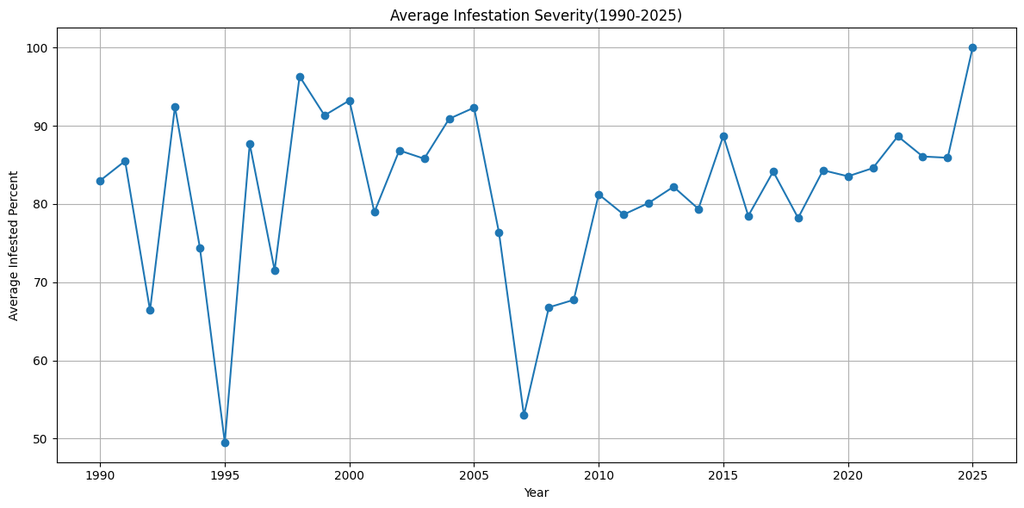

```python
# Line Plot for visual clarity as well
plt.figure(figsize=(12, 6))
plt.plot(year_avg.index, year_avg.values, marker='o')
plt.title('Average Infestation Severity(1990-2025)')
plt.xlabel('Year')
plt.ylabel('Average Infested Percent')
plt.grid(True)
plt.tight_layout()
plt.show()
```

# Question 6 Conclusion

From both the line plot as well as the table, we can see clear fluctuations over time. Only recently though, it seems that the trend is upward reaching its peak without sign of going downward. This could indicate a worsening of infestation levels or more optimistically, a sign of better reporting practices and monitoring. Either way with the majority above 80 percent, we can see that invasive plant species need to be regulated and better handled going forward.

## Final Statements

I hope throughout this notebook you have become more aware about invasive plant species and the threat that they truly are. I also hope that you have grown a deeper appreciation for data science and the powerful insights it can provide. Thank you for reading.